# QC Notes, Genomics Data, Final Report

## Abstract

This report is the asme as previous, with the agreed samples / timepoints removed.

# Mapping indicators

### Basic mapping stats

Data from the aligner (`bowtie2`) log files. These are ordered by total number of paired end reads per timepoint.

| Timep | P.tot | P.1 | P.mul | P.dis | SE.1 | SE.mul | SE.0 | PE.0 | map.pe | map.se | Sample |
| --- | --- | --- | --- | --- | --- | --- | --- | --- | --- | --- | --- |
| C3011.CSM67UEW | 25720 | NA | NA | NA | 3707 | 13270 | 8743 | NA | NA | NA | C3011 |
| C3011.CSM7KOMP | 33767 | NA | NA | NA | 4981 | 21473 | 7313 | NA | NA | NA | C3011 |
| C3012.CSM7KON8 | 119287 | NA | NA | NA | 27276 | 84548 | 7463 | NA | NA | NA | C3012 |
| P6028.PSM7J177 | 647317 | NA | NA | NA | 145324 | 421720 | 80273 | NA | NA | NA | P6028 |
| H4019.HSM7J4PK | 717613 | NA | NA | NA | 4611 | 32607 | 680395 | NA | NA | NA | H4019 |
| M2026.MSM6J2OP | 762935 | NA | NA | NA | 147349 | 575816 | 39770 | NA | NA | NA | M2026 |
| P6028.PSM7J17B | 809985 | NA | NA | NA | 133265 | 461664 | 215056 | NA | NA | NA | P6028 |
| M2008.MSM5LLDI | 1088594 | NA | NA | NA | 169896 | 817814 | 100884 | NA | NA | NA | M2008 |
| P6028.PSM7J163 | 1141843 | NA | NA | NA | 185161 | 702148 | 254534 | NA | NA | NA | P6028 |
| C3013.CSM7KONU | 1251869 | NA | NA | NA | 212759 | 740077 | 299033 | NA | NA | NA | C3013 |

[output cut: 711 more lines]

In this table:

| Column | Description |
| --- | --- |
| Timep | Sample-Timepoint combination, in the form SAMPLE.TPid |
| P.tot | Total number of paired end reads sequenced |
| P.1 | Number of PE reads with a single unique mapping |
| P.mul | Number of PE reads with multiple ambiguous mappings |
| P.dis | Number of PE reads with mates mapping to different chromosomes |
| SE.1 | (PE reads that did not map treated as 2 single end reads) Single end reads with unique mapping |
| SE.mul | (Same) Single end reads with multiple ambiguous mapping |
| SE.0 | (Same) Single end reads with no mapping |
| PE.0 | Paired end reads with no mapping |
| map.pe | Paired end alignment efficiency, as $map_{pe} = \frac{P_1 + P_{mul} + P_{dis}}{P_{tot}}$ |
| map.se | Single end alignment efficiency, as $map_{se} = \frac{SE_1 + SE_{mul}}{2(P_0 - P_{dis})}$ |

[output not shown]

Mapping of metagenomics data is towards a sample-specific metagenomic reference containing all species ever identified for all time points of this individual.

### Summarised by individual

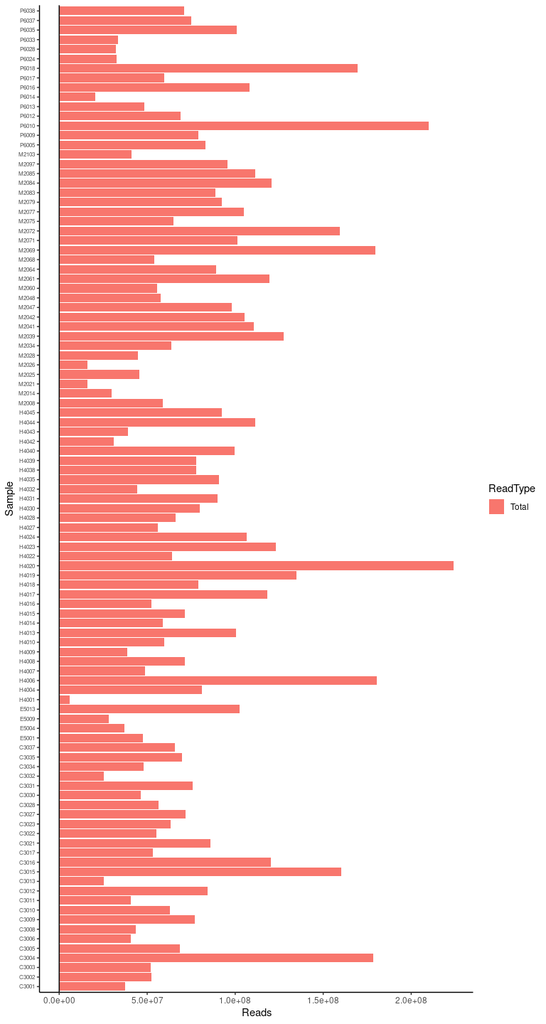

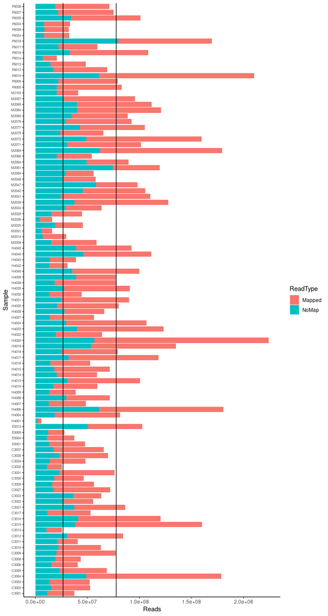

### Data from the feature counting (`subread featurecounts`)

(Uses data from BAM file, should be essentially same as previous)

This graph shows absolute number of mapped reads counted towards ORF / CDS at each timepoint for all individuals. The solid lines are the mean read counts across all.

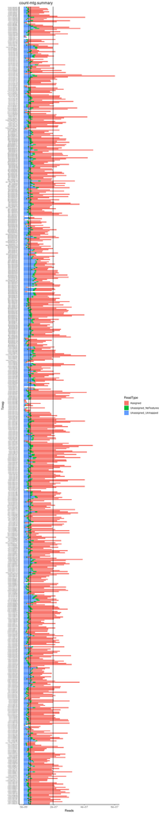

There are some individuals / timepoints with very low read counts overall.

The following graph shows the relative distribution of mapped reads (the non-plotted fraction to 100% are ambiguously mapped reads).

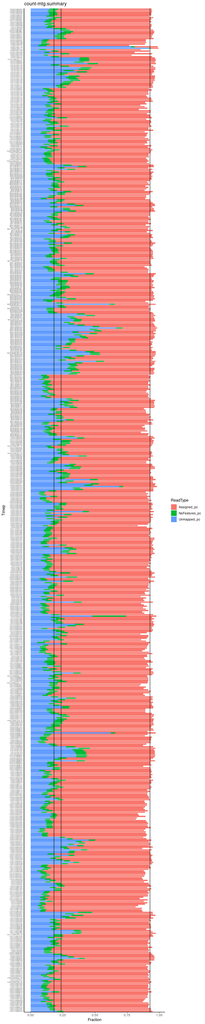

### Summary per individual

Total number of mapped reads:

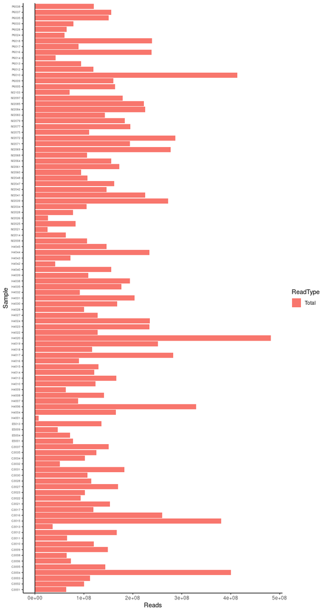

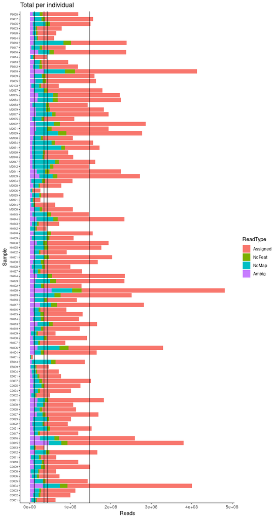

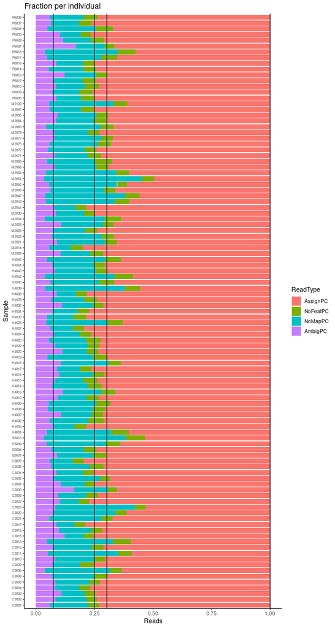

### Sample / Timepoint exclusion

After exclusion of pathological samples, results have a minimum of reads.

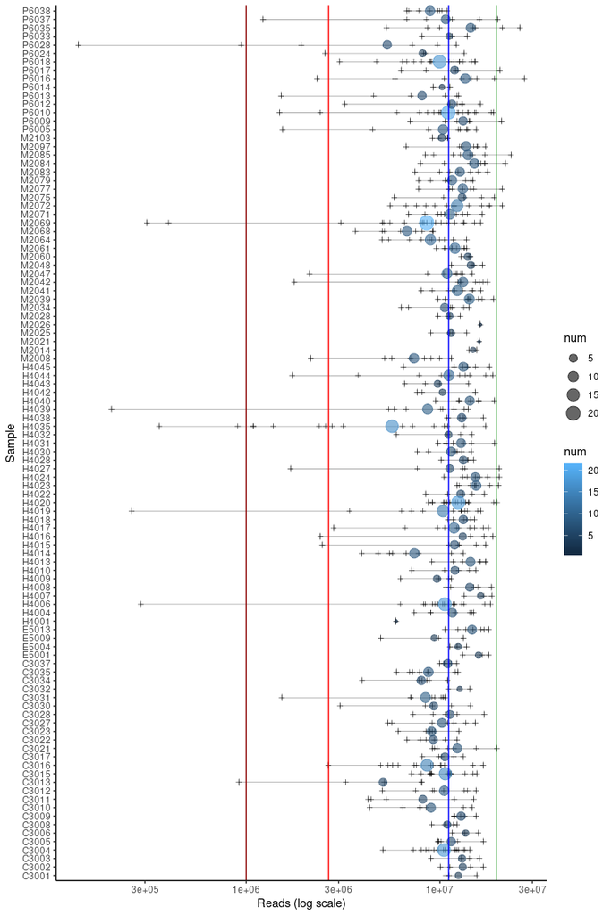

Reads scale is logarithmic to enhance the difference in the minimum total number of PE reads per timepoint for some individuals.  
The limits (coloured lines) correspond to 1MM reads (dark red), mean minus 2 standard dev (2.67MM reads, red), mean (11.1MM reads, blue) and mean plus 2 standard deviations (19.5MM reads, green). The bars extend from minimum number of reads per timepoint (of individual) to maximum. Dot is the mean number, size and color indicate number of timepoints.

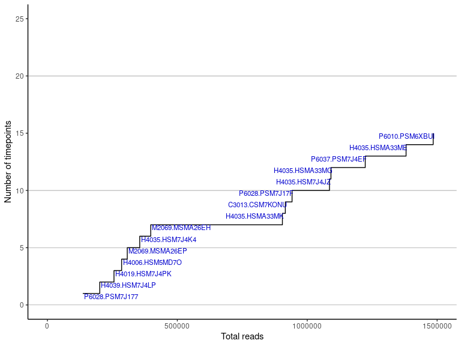